# 3rd Assignment. Frank Wolfe algorithm

Arnau Mercader Luque

## Introduction

In this work we present a solution for equilibrium traffic assignment problem. The algorithm is based on the concepts of simplicial decomposition, regularization and partial linearization. In this assigment, we consider an integrable linear delay cost function. For link $(i,j)$, the equation is: $s_{ij} = c_{ij} + d_{ij} x$, where $c_{ij}$,$d_{ij}$ are taken from the corresponding values $c,d$ in the data set.

We have an instance of 7 nodes, and consider the nodes 1-3 as origins and 6-7 as destinations. So we have the next o-d pairs:

```
(1,6)
(1,7)
(3,6)
(3,7)
```

## Graphical representation of the network

In the next graph, we represented the network associated with our instance. Green colors are destinations and orange colors origins:

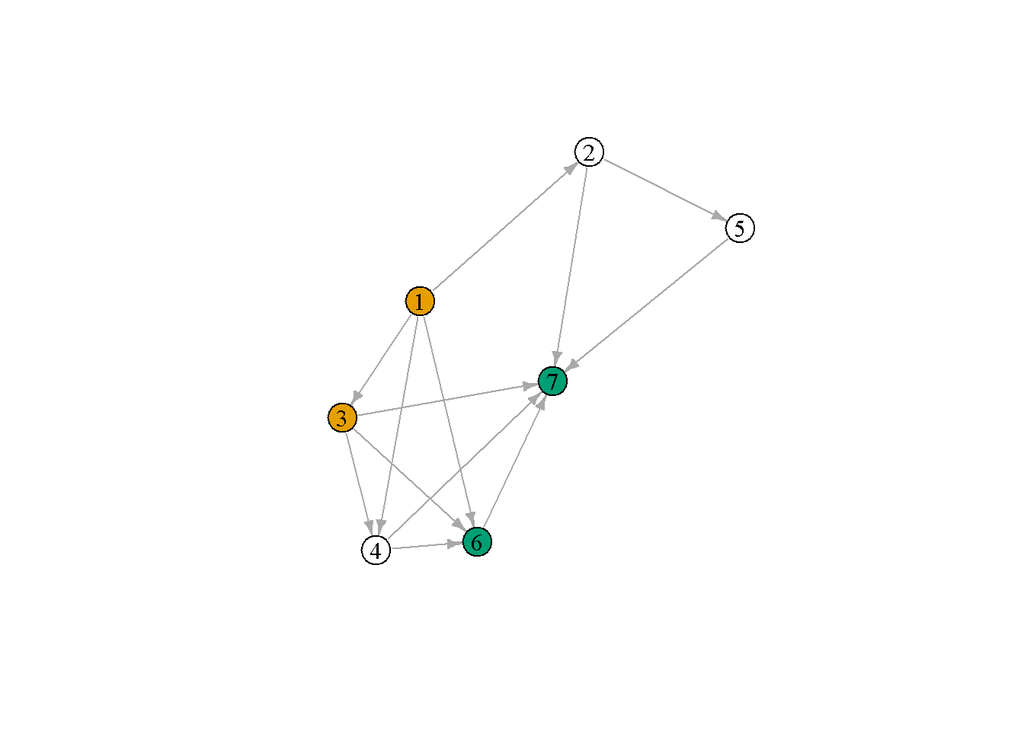

## Idea of the algorithm

We formulate the problem in terms of paths (routes) between o-d pairs. The simplicial decomposition approach can be viewed as a column generation approach. Consider a subset of k paths , we solve a master problem (MP) and evaluate this solution to other problem. If optimal path flows are optimal in MP are also optimal in other problem. The idea is to evaluate the arc flows and the gradient of the objective function. By the Caratheodory theorem, any feasible point of bounded polytype can be expressed as a convex combination of its extreme points, and it’s obtained by the MP.

The quadratic function to minimize is: $\displaystyle \sum c_{ij}\;x + \displaystyle \sum \frac{1}{2} d_{ij} \;x^2$ subject to supply the o-d pairs flow in the network.

## Introduction

The class of simplicial decomposition (SD) schemes have shown to provide eﬃcient tools for nonlinear network ﬂows. Shortest subproblems are solved in order to generate extreme points of the polyhedron of feasible ﬂows, and, alternately, master problems are solved over the convex hull of the generated extreme points. We review the development of simplicial decomposition and the closely related column generation methods.

Simplicial decomposition (SD) algorithms based on Carathéodory’s theorem (modification of Frank-Wolfe). A direct consequence of this theorem is that any point in a bounded polyhedral set X can be described by a convex combination of its extreme points. In SD algorithms, extreme points are generated algorithmically by the solution of the linear Frank-Wolfe subproblem. Alternately, a so called master problem, deﬁned by a restricted set of extreme points, is solved in order to generate a new iteration point.

Steps of the algorithm:

1. Solve subproblem (gradient of the objective function): $c_{ij} + d_{ij}\;x$.

First we solve the subproblem with an initial value of $t0 = 1$ to generate a bad initial solution of the Sub-Problem. After that we increase the sets **Ws** and then solve the **Master Problem** (MP). With the values of the **MP** whe are going to fix a new value to $t0$ based on the gradient of the **quadratic function** evaluated in **vv** obtained in the resolution of **MP** where **vvv** is the sets **Wx** multiplied by their associated $\alpha_{i = 1..n}$.

2. Update working sets: Add new vertex and remove with information of $\alpha$ (MP variable) the smaller baricentric coordinate (small value of $\alpha$). When we say small is in terms of zero or closeness to zero.

When we arrive at a point where the dimensions of **Ws** is equal to **rho** we have to modify the columns of **Ws** based on the the associated values of $\alpha$. To do that we will choose the smallest value of vector of $\alpha$ (associated to the baricentric coordinates of vertexs) and change this column with the value obtained in the new resolution of **SP**.

3. Update best lower bound (BLB) and calculate gap. When the **GAP** will be close to zero or the number of iterations arrive to 500 the algorithm will stop.

In step 3, we will update the **BLB** as: $max(BLB,f(x^v)+\nabla_xf(x^v)^T(\hat{x}^v-x^v))$ and gap as: $\frac{f(x^v-BLB)}{BLB}$. With this criterion we will ensure that our **BLB** and the value of the **f.obj** will converge and the gap will tend to zero.

We stop iterating if $gap < 0.005$ or iteration number is equal to 500.

4. Solve MP: Minimize quadratic function subject to actual working set, or in other words, solve problem with a convex combination of extreme points obtained in previous steps. *Go to step 1*.

At this point, we will use the set of combinations, called **W** (solutions obtained solving at each step the SP) to solve the MP and obtain the optimal solution of the algorithm or new points (combinations of origen destination flows) to use in the SP as a combination of origen destination flows multiplied by $\alpha_{i = 1..n}$.

We start algorithm with **BLB** = $-\infty$. The goal is to observe how the **MP** and **BLB** will become closer at every iteration.

## Printout of the iterations